# TO 414 Final Project

Group 8: Matthew Davis, Alec Drean, Changxin Miao, Sonia Shekar, and Mara Van Sickle  
Fall 2016

## Agenda

Introduction

Methodology

Initial Visualization

Understanding Matches

Modeling and Analysis

Conclusion

## Introduction

Objective

- Primary: Create model to predict whether or not two individuals will match after a speed dating encounter in order to improve business operations
- Secondary: Gain insight into speed dating data and variables that influence match success

The Data:

- Response Variable
  - Match or No Match
- Predictor Variables
  - Demographic Data
  - Partner Attribute Rankings
  - Preference/Response Rankings Over Time

## Methodology

Data Cleanup

- Variable Class Changes
- Merge Individual & Partner Information
- Variable Standardization

Initial Match Visualization

- Response (Match vs. No Match) Logistic Regression

Machine Learning Algorithm

- Random Forest

## Data Cleaning

We begin by downloading the data into a table that we will work with to run our analysis. This table, or data frame, is called “datedata”.

To convert the data into workable form, we perform the following 3 operations on the new frame, “datedata.”

- Variable Class Changes
  - For variables that take the form factor, we convert them to that classs to ensure they have the proper treatment in our models.
- Merge Individual and Partner Information
  - Since our ultimate goal is to predict a match based off of the information 2 partners fill out prior to their date, we create a data frame that lists all of the pertinent demographic and survey information onto 1 line of the dataframe.
- Variable Standardization
  - In order to run a randomForest model, we must impute missing values onto to the dataset. Since we are dealing with a generally homogenous group being they all attend Columbia, we take the average of each value we are imputing and fill it in as the missing data point.

## Initial Visualization

Before diving into models predicting successful matches, let's take a step back and understand the individuals who participated in speed dating. Let's explore:

- Gender
- Race Distribution by Gender
- The Importance of Partner's Race
- Speed Dating Goals by Gender
- Going Out Habits by Gender
- Dating Habits by Gender

### Initial Visualization

A simple place to begin is with gender. Do we have an even match between men and women?

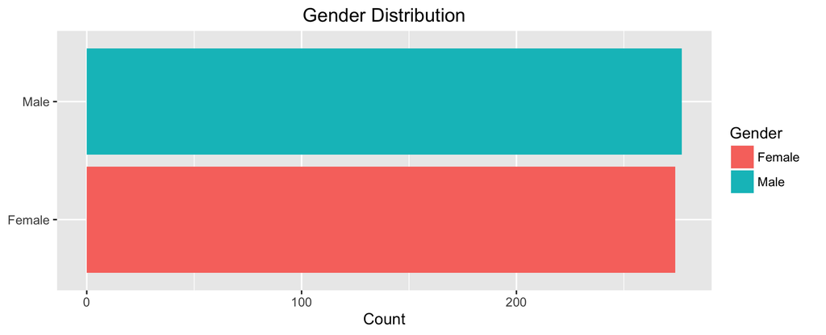

It appears that we are almost perfectly 50/50, with 277 males and 274 females participating.

### Initial Visualization

The next interaction to observe is between race and the preference of race. Gender 0 is female and Gender 1 is male.

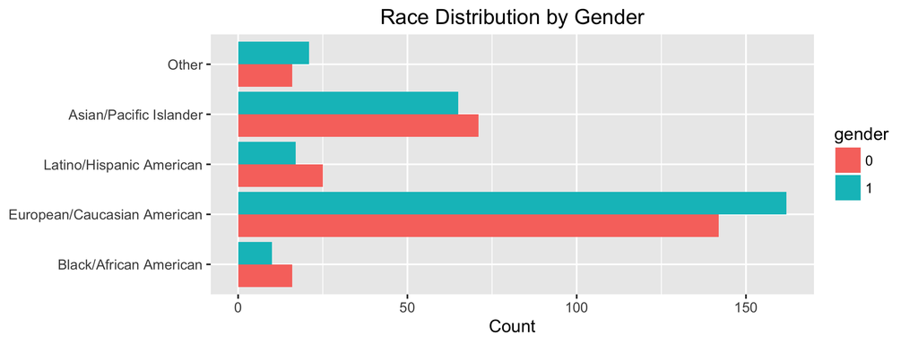

As we can see here, the population of individuals in not incredibly diverse. Native Americans were not included in the speed dating pool, so they did not appear in our analysis. As the graph shows, the population is over 50% white. The next largest population, Asian individuals, is as large as all of the other groups combined.

### Initial Visualization

We want to see if individuals of different races place more or less weight on the race of their partner when speed dating.

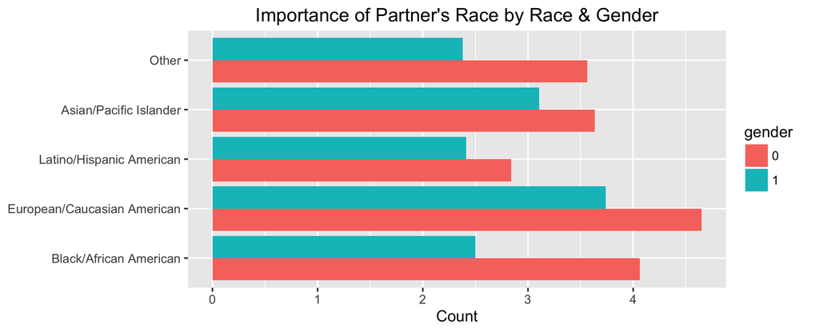

### Initial Visualization

Social/Relationship Habits

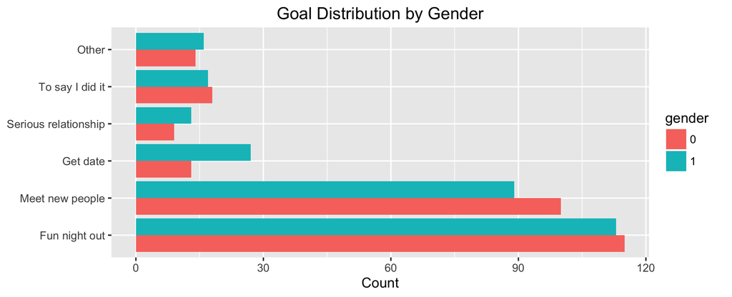

As you can see from the above plot, most people's intentions in attending the speed dating event skew towards more casual objectives, like meeting new people and having a fun night, rather than begin a serious relationship. What is worthy of noting is that twice as many males have a goal of getting a date than females.

### Initial Visualization

Frequency of Going Out

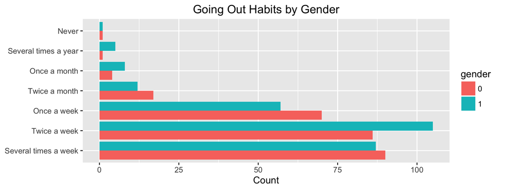

Contrary to the dating plot, this plot revelas that speed dating participants skew towards going out frequently, where the dating habit plot reveals that participants skew towards infrequent dating.

While there are many other demographic variables, we believe those mentioned provide a base level of insight into the individuals who participate in speed dating.

### Initial Visualization

Dating Experiences

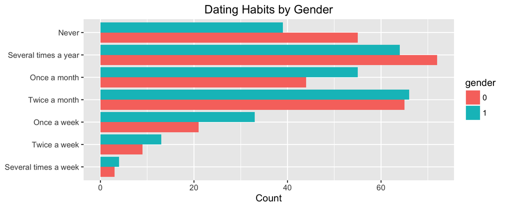

## Understanding Decisions

The next portion of our analysis will look at matches. We want to understand the number of matches that occurred and the factors that affect a match.

We analyze the following information about our participants:

- The Number of Matches
- The Distribution of Decisions

### Understanding Decisions

We found that there were **690** matches and **3494** no-matches.

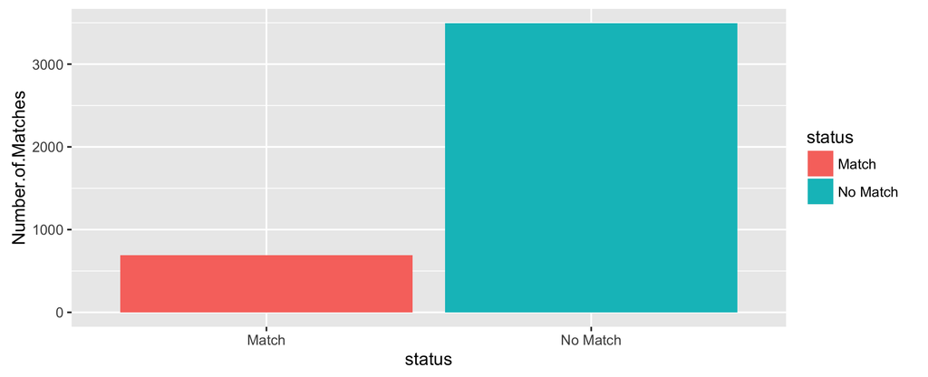

Here we see the breakdown of the match data. Clearly, there are many more non-matches than matches!

## Understanding Decisions

Taking this information one step forward, we can compare decisions to matches. At the end of speed dating event, each person must make a yes/no decision for each partner they met with throughout the night. For example, say a woman was filling out her form at the end of the night. She would have to evaluate each male partner she met that night to make a decisions of yes, I would like to see this person again, or no, I do not want to see this person again. If she makes a yes decision for a man and that same man makes a yes for her, it's a match! However, many yes decisions often go unreciprocated.

As a result, we create a new variable that merges an individual's data with their partner's. If both parties make a decision for yes, the value is two. If only one party makes a yes decision, the value is one. Lastly, a value of zero means both parties decided no. The data breaks down as follows:

### Understanding Decisions

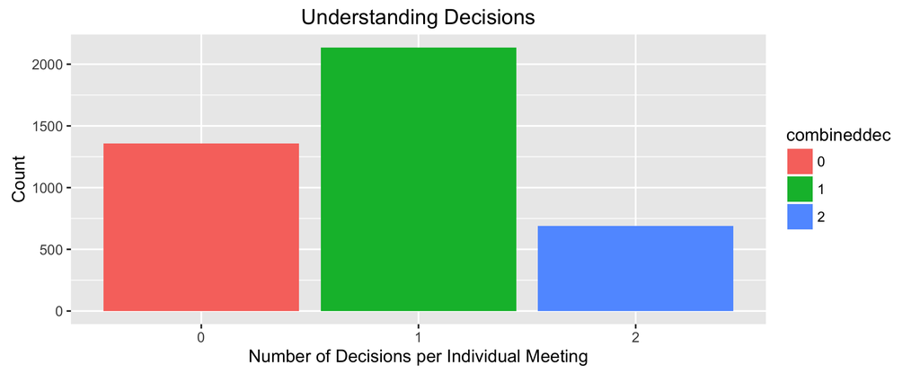

As we can see, the majority of no-matches are actually single sided decisions, in other words one person made a decision to want to match, but the partner did not reciprocate that decision.

### Understanding Decisions

Survey Results over Time

Here we look at how survey responses on importance of characteristics differ over time

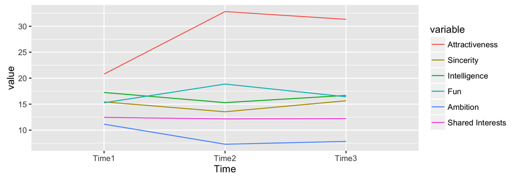

For the most part, there is consistency over time for sincereity, intelligence, fun, ambition, and shared interests. The exception lies in attractiveness. Over time, individuals say that attractiveness played a greater role in their decision than they originally said it did. We contribute this change to hindsight. Over time, people probably recognize they learned very little about their partner in 5 minutes. The only solidified thing they could walk away with is attractiveness.

### Understanding Decisions: Ratings for a Yes/No Decision

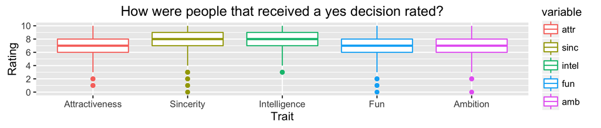

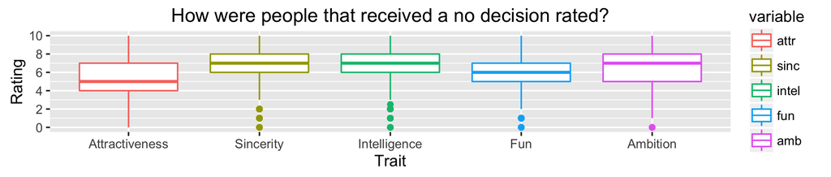

### Understanding Decisions

Order's Influence on Matches

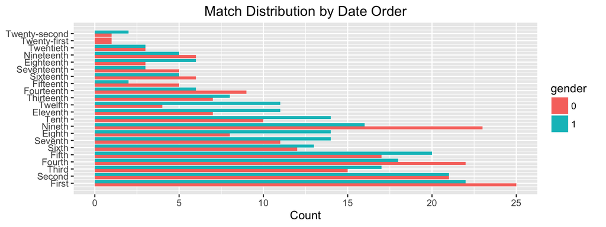

This data shows the number of matches made by people who met in the first round of the night (order = 1) and so on. With the exception of women making more matches in round 9, the majority of matches are made toward the beginning of the night.

It's also important to note that many waves have fewer than 10 rounds, so there are fewer counts for order values greater than 11.

### Logistic Regression Results

The first logistic regression model we begin with is an understanding of the intended careers of males(x) and females(y) to see what variables predict a match. We run two seperate models so that the intercept can be interpreted properly as when the male or female is a lawyer. The first call is for male.

```
Call:  glm(formula = match1 ~ career_c.x2 + career_c.x3 + career_c.x4 +
    career_c.x5 + career_c.x6 + career_c.x7 + career_c.x8 + career_c.x9 +
    career_c.x10 + career_c.x11 + career_c.x12 + career_c.x13 +
    career_c.x14 + career_c.x15 + career_c.x16 + career_c.x17,
    family = "binomial", data = newdate_n, na.action = "na.exclude")

Coefficients:
 (Intercept)   career_c.x2   career_c.x3   career_c.x4   career_c.x5
   -1.456552     -0.272790      1.051087     -0.425233     -0.047525
 career_c.x6   career_c.x7   career_c.x8   career_c.x9  career_c.x10
   -0.134537     -0.087483     -0.460370     -0.383997     -0.779588
career_c.x11  career_c.x12  career_c.x13  career_c.x14  career_c.x15
          NA            NA     -0.307036      0.609254      0.009633
career_c.x16  career_c.x17
          NA     -0.740672

Degrees of Freedom: 4144 Total (i.e. Null);  4131 Residual
  (39 observations deleted due to missingness)
Null Deviance:      3716
Residual Deviance: 3695     AIC: 3723
```

## Logistic Results: Career

Model Summary for female:

```
Call:  glm(formula = match1 ~ career_c.y2 + career_c.y3 + career_c.y4 +
    career_c.y5 + career_c.y6 + career_c.y7 + career_c.y8 + career_c.y9 +
    career_c.y10 + career_c.y11 + career_c.y12 + career_c.y13 +
    career_c.y14 + career_c.y15 + career_c.y16 + career_c.y17,
    family = "binomial", data = newdate_n, na.action = "na.exclude")

Coefficients:
 (Intercept)   career_c.y2   career_c.y3   career_c.y4   career_c.y5
     -1.2910       -0.3759       -0.1534       -0.1421       -0.7127
 career_c.y6   career_c.y7   career_c.y8   career_c.y9  career_c.y10
     -0.4377       -0.1580            NA       -0.4663       -0.4709
career_c.y11  career_c.y12  career_c.y13  career_c.y14  career_c.y15
     -0.3740       -2.0049      -14.2751            NA       -1.2740
career_c.y16  career_c.y17
     -0.2131            NA

Degrees of Freedom: 4084 Total (i.e. Null);  4071 Residual
  (99 observations deleted due to missingness)
Null Deviance:      3656
Residual Deviance: 3622     AIC: 3650
```

### Logistic Results: Career

From the regression model results given by Log Model A for Males, the careers that were statistically significant at the 95% confidence interval level were:

- Career 1: Lawyer (-)
- Career 3: Psychologist (+)
- Career 10: Undecided (-)

Female Career

From the regression model results given by Log Model A for Females, the careers that were statistically significant at the 95% confidence interval level were:

- Career 1: Lawyer (-)
- Career 2: Academic/Research (-)
- Career 5: Engineer (-)
- Career 6: Creative Arts/Entertatinment (-)
- Career 9: International/Human Affairs (-)
- Career 10: Undecided (-)

The symbol +/i next to each interest indicates what a unit change in their value does to the predicted log odds of a match.

### Logistic Regression: Expectations

The second question we asked was how did expectations for the night affect the odds of a match? We created a second logistic regression model to address this using the following questions: 1. Overall, on a scale of 1-10, how happy do you expect to be with the people you meet during the speed-dating event? 2. Out of the 20 people you will meet, how many do you expect will be interested in dating you?

Our findings indicated that when both partners increased their expectations about the number of people that were interested in meeting them, it was statistically significant in predicting a match. For women, expectation of happiness was statistically significant and a positive indicator of increasing the likelihood of a match.

## Logistic Results: Expectations Model Summary

```
Call:  glm(formula = match1 ~ exphappy.x + expnum.x + exphappy.y + expnum.y,
    family = "binomial", data = newdate_n, na.action = "na.exclude")

Coefficients:
(Intercept)   exphappy.x     expnum.x   exphappy.y     expnum.y
   -2.78479      0.01967      0.06657      0.05151      0.07042

Degrees of Freedom: 4183 Total (i.e. Null);  4179 Residual
Null Deviance:      3747
Residual Deviance: 3706     AIC: 3716
```

```
Call:  glm(formula = match1 ~ sports.x + tvsports.x + exercise.x + dining.x +
    museums.x + art.x + hiking.x + gaming.x + clubbing.x + reading.x +
    tv.x + theater.x + movies.x + concerts.x + music.x + shopping.x +
    yoga.x + sports.y + tvsports.y + exercise.y + dining.y +
    museums.y + art.y + hiking.y + gaming.y + clubbing.y + reading.y +
    tv.y + theater.y + movies.y + concerts.y + music.y + shopping.y +
    yoga.y, family = "binomial", data = newdate_n, na.action = "na.exclude")

Coefficients:
(Intercept)     sports.x   tvsports.x   exercise.x     dining.x
 -3.2087933    0.0203070    0.0005853    0.0206042    0.0727703
  museums.x        art.x     hiking.x     gaming.x   clubbing.x
 -0.1342820    0.0934102    0.0122123   -0.0049991    0.0459339
  reading.x         tv.x    theater.x     movies.x   concerts.x
  0.0670426   -0.0129507   -0.0316116   -0.0597399   -0.0069762
    music.x   shopping.x       yoga.x     sports.y   tvsports.y
  0.0496331   -0.0194456    0.0253655    0.0432900   -0.0581441
 exercise.y     dining.y    museums.y        art.y     hiking.y
 -0.0236998   -0.0132051   -0.0156526    0.0865017    0.0017728
   gaming.y   clubbing.y    reading.y         tv.y    theater.y
  0.0174007    0.0754885    0.0044915    0.0489897    0.0197496
   movies.y   concerts.y      music.y   shopping.y       yoga.y
 -0.0954358    0.1036264   -0.0642404   -0.0267692    0.0149017

Degrees of Freedom: 4183 Total (i.e. Null);  4149 Residual
Null Deviance:      3747
Residual Deviance: 3630     AIC: 3700
```

### Logistic Results: Interests

The third question asked for our client was how did various interests of each partner do as predictors of a match.

For males, we find the following interests as good predictors of a match:

- dining(+)
- museums(-)
- art(+)
- clubbing(+)
- reading(+)
- movies(-)

For females, we find the following interests as good predictors of a match:

- tvsports(-)
- art(+)
- clubbing(+)
- tv(+)
- movies(-)
- concerts(+)

The symbol +/i next to each interest indicates what a unit change in their value does to the predicted log odds of a match.

## Logistic Results: Going Out

```
Call:  glm(formula = match1 ~ date.x2 + date.x3 + date.x4 + date.x5 +
    date.x6 + date.x7 + go_out.x2 + go_out.x3 + go_out.x4 + go_out.x5 +
    go_out.x6 + go_out.x7, family = "binomial", data = newdate_n,
    na.action = "na.exclude")

Coefficients:
(Intercept)      date.x2      date.x3      date.x4      date.x5
    -0.3365      -0.8187      -0.9408      -0.9519      -1.3219
    date.x6      date.x7    go_out.x2    go_out.x3    go_out.x4
    -1.2827      -1.3194      -0.1679      -0.2264      -0.8808
  go_out.x5    go_out.x6    go_out.x7
    -0.9058      -0.1725     -12.9102

Degrees of Freedom: 4145 Total (i.e. Null);  4133 Residual
  (38 observations deleted due to missingness)
Null Deviance:      3713
Residual Deviance: 3638     AIC: 3664
```

```
Call:  glm(formula = match1 ~ date.y2 + date.y3 + date.y4 + date.y5 +
    date.y6 + date.y7 + go_out.y2 + go_out.y3 + go_out.y4 + go_out.y5 +
    go_out.y6 + go_out.y7, family = "binomial", data = newdate_n,
    na.action = "na.exclude")

Coefficients:
(Intercept)      date.y2      date.y3      date.y4      date.y5
   -1.41369     -0.04984      0.11231     -0.16312      0.00535
    date.y6      date.y7    go_out.y2    go_out.y3    go_out.y4
   -0.27748     -0.10135     -0.11523     -0.16062     -0.10884
  go_out.y5    go_out.y6    go_out.y7
    0.51815     -0.56012     -1.31817

Degrees of Freedom: 4124 Total (i.e. Null);  4112 Residual
  (59 observations deleted due to missingness)
Null Deviance:      3693
Residual Deviance: 3676     AIC: 3702
```

### Logistic Results: Going Out

Given that we are dealing with dummmy variables for the date and go_out variables, we create two seperate gender models to predict a match so that the intercept can be properly interpreted.

For the males, we see the following variables as good predictors of a match:

- datex2 (-)
- datex3 (-)
- datex4 (-)
- datex5 (-)
- datex6 (-)
- datex7 (-)

Interestingly enough, in all cases they decrease the odds of a match.

For the women, the variable is a much worse of a predictor. Only the intercept is statistically significant.

Overall it appears, that the number of dates that men go on can be used as a good predictor for whether or not a match, but not for women.

## Logistic Results: Perception

```
Call:  glm(formula = match1 ~ attr3_1.x + sinc3_1.x + fun3_1.x + intel3_1.x +
    amb3_1.x + attr3_1.y + sinc3_1.y + fun3_1.y + intel3_1.y +
    amb3_1.y, family = "binomial", data = newdate_n, na.action = "na.exclude")

Coefficients:
(Intercept)    attr3_1.x    sinc3_1.x     fun3_1.x   intel3_1.x
  -2.275804     0.009713    -0.020299     0.141149    -0.027637
   amb3_1.x    attr3_1.y    sinc3_1.y     fun3_1.y   intel3_1.y
   0.034100     0.073236    -0.031547     0.029141    -0.037997
   amb3_1.y
  -0.071464

Degrees of Freedom: 4116 Total (i.e. Null);  4106 Residual
  (67 observations deleted due to missingness)
Null Deviance:      3670
Residual Deviance: 3624     AIC: 3646
```

## Logisitc Results: Perception

Finally, we take a look at people's perception of themselves has any effect on predicting a match. On the survey prior to coming to the event, they were asked the question: “How do you think you measure up? Please rate your opinion of your own attributes, on a scale of 1-10 (be honest!)”

Examining the results of the regression, the following survey responses for men were statistically significant:

- fun(+)

For women, the following survey responses were statistically significant:

- Attractiveness (+)
- Ambition (-)

Overall, the results tell a mixed tale for women. On one hand, the more attractive a female sees themselves the more likely a match. Conversely, the more ambitious a woman sees herself, the less likely a match. Since both traits can be seen as a proxy for confidence, it appears that it is important to predicting a match, but it depends what kind of confidence is projected by the female participant.

For men, how fun they perceive themselves is a good indicator of a match. Given this, it may be good for the company to prescreen male applicants based on how fun and outgoing they appear to be, to increase the quality of the pool.

### Random Forest Model: Predicting a Decision

We use several parameters to tune the process, and the final model we select is the model with the following metrics:

- Accuracy of **72%**
- Kappa statistic of **0.42**

### Random Forest Model: Predicting a Decision

Mean Decrease in Gini

```
             rn MeanDecreaseGini
  1:   int_corr        14.547343
  2:   samerace         3.703995
  3:      age_o        10.359932
  4:     race_o         5.633254
  5:   pf_o_att         8.663021
 ---
189:  attr5_1.y         6.743921
190:  sinc5_1.y         7.243669
191: intel5_1.y         8.114607
192:   fun5_1.y         7.946589
193:   amb5_1.y         8.305302
```

### Random Forest Model: Predicting a Decision

Plot of Variable Importance

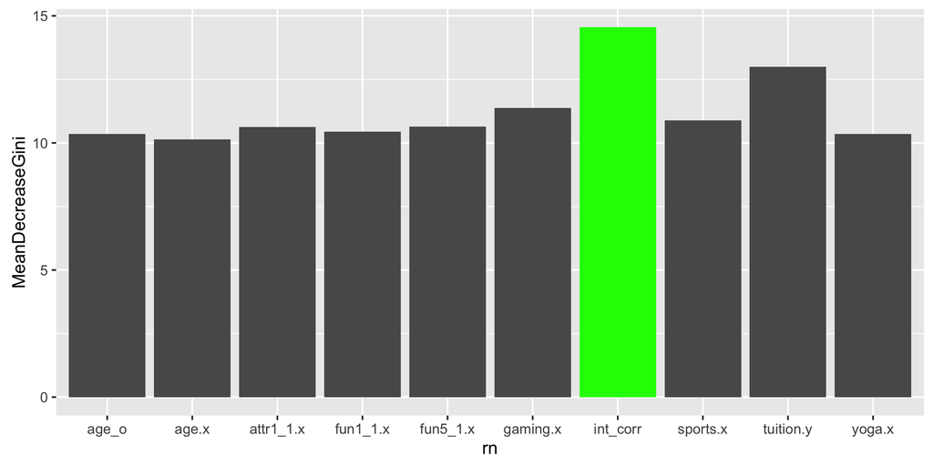

### Random Forest Model: Predicting a Match

We used the person’s stated preferences, his demographical backgrounds and responses in the survey before the date.

We use several parameters to tune the process, the final model we select is the model with the following performance metrics:

- Accuracy of **84%**
- Kappa statistic of **0.054**

Variable importance concluded from Mean Decrease Gini statistics (from high to low) are as follows:

- Int_corr
- Tuition.y
- Income.y
- Attr2_1.x
- Clubbing.x

> **Interpretation:** When the company tries to predict whether two people will match or not, it is important for them to assign more weights to factors above.

### Random Forest Model: Predicting a Match

Mean Decrease in Gini

```r
contribution_rf<-as.data.frame(importance(m_rf$finalModel))

setDT(contribution_rf, keep.rownames = TRUE)[]
```

```
             rn MeanDecreaseGini
  1:   int_corr        20.151434
  2:   samerace         3.067061
  3:      age_o         8.028601
  4:     race_o         3.289539
  5:   pf_o_att         5.548158
 ---
189:  attr5_1.y         3.761585
190:  sinc5_1.y         4.695568
191: intel5_1.y         4.353446
192:   fun5_1.y         5.006494
193:   amb5_1.y         5.048342
```

```r
contribution_rf_high<-contribution_rf[contribution_rf$MeanDecreaseGini>7.5,]
```

### Random Forest Model: Predicting a Match

Plot of Match Prediction Variable Importance

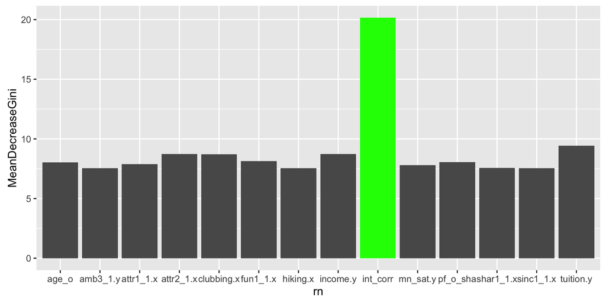